# Assignment 4

PGIS/M/DTS/20/09

8/13/2021

```r
library(dplyr)
library(lavaan)
ds <- read.csv("./academicachievement.csv")
head(ds)
```

```
##   motivation    harmony stability parentalpsy        ses    verbal      read
## 1  -7.907122  -5.075312 -3.138836  -17.800210   4.766450 -3.633360 -3.488981
## 2   1.751478  -4.155847  3.520752    7.009367  -6.048681 -7.693461 -4.520552
## 3  14.472570  -4.540677  4.070600   23.734260 -16.970670 -3.909941 -4.818170
## 4  -1.165421  -5.668406  2.600437    1.493158   1.396363 21.409450 -3.138441
## 5  -4.222899 -10.072150 -6.030737   -5.985864 -18.376400 -1.438816 -2.009742
## 6   4.868769   3.029841 -7.648277   14.668790  -2.235039 -6.826892  0.822650
##       arith     spell
## 1 -9.989121 -6.567873
## 2  8.196238  8.778973
## 3  7.529984 -5.688716
## 4  5.730547 -2.915676
## 5 -0.623953 -1.024624
## 6  5.045174  0.904154
```

Now , we write the model, then fit the model using lavaan syntax

```r
model <- '
  # measurement model
    adj =~ motivation + harmony + stability
    risk =~ parentalpsy + ses + verbal
    achiv =~ read + arith + spell
  # regressions
    adj ~ risk
    achiv ~ adj + risk

  #residual correlation
  motivation ~~ read
  parentalpsy ~~ verbal + arith
  stability ~~ spell
  arith ~~ harmony
  stability ~~ parentalpsy
'
```

```r
fit <- sem(model, data = ds)
```

```r
summary(fit,standardized = TRUE,  fit.measures=TRUE)
```

```
## lavaan 0.6-9 ended normally after 167 iterations
##
##   Estimator                                         ML
##   Optimization method                           NLMINB
##   Number of model parameters                        27
##
##   Number of observations                           500
##
## Model Test User Model:
##
##   Test statistic                               120.125
##   Degrees of freedom                                18
##   P-value (Chi-square)                           0.000
##
## Model Test Baseline Model:
##
##   Test statistic                              2597.972
##   Degrees of freedom                                36
##   P-value                                        0.000
##
## User Model versus Baseline Model:
##
##   Comparative Fit Index (CFI)                    0.960
##   Tucker-Lewis Index (TLI)                       0.920
##
## Loglikelihood and Information Criteria:
##
##   Loglikelihood user model (H0)             -15503.428
##   Loglikelihood unrestricted model (H1)     -15443.366
##
##   Akaike (AIC)                               31060.857
##   Bayesian (BIC)                             31174.651
##   Sample-size adjusted Bayesian (BIC)        31088.952
##
## Root Mean Square Error of Approximation:
##
##   RMSEA                                          0.107
##   90 Percent confidence interval - lower         0.089
##   90 Percent confidence interval - upper         0.125
##   P-value RMSEA <= 0.05                          0.000
```

[output cut: 47 more lines]

```
##
## Variances:
##                    Estimate  Std.Err  z-value  P(>|z|)   Std.lv  Std.all
##    .motivation       10.067    2.925    3.442    0.001   10.067    0.103
##    .harmony          35.125    3.053   11.506    0.000   35.125    0.352
##    .stability        59.932    4.065   14.743    0.000   59.932    0.601
##    .parentalpsy      63.721    5.886   10.826    0.000   63.721    0.634
##    .ses              65.094    5.008   12.998    0.000   65.094    0.652
##    .verbal           43.569    5.833    7.470    0.000   43.569    0.437
##    .read             10.351    1.602    6.461    0.000   10.351    0.102
##    .arith            37.221    2.616   14.228    0.000   37.221    0.376
##    .spell            16.525    1.677    9.855    0.000   16.525    0.166
##    .adj              67.174    6.015   11.167    0.000    0.770    0.770
##     risk             36.842    6.526    5.646    0.000    1.000    1.000
##    .achiv            32.233    3.646    8.841    0.000    0.354    0.354
```

Model Test User Model and Model Test Baseline Model P values are less than 0.05 model seems not significant. But the CFI and TLI values are greater than 0.90 because of that we can assume that we have a good fit. RMSEA value should be less than 0.05 but it is greater than 0.05. SRMR Value is less than 0.05 and we can consider it as good value.

Latent variables P values are (less than 0.05) significant. Regression relations ships are also significant( P values less than 0.05).

However, we can note that following covariances and variances are not significant, since the p value is > 0.05

stability ~~ parentalpsy harmony ~~ arith stability ~~ spell parentalpsy ~~ verbal

We remove the nonsignificant covariances ,and refit the model.

```r
modificationIndices(fit, minimum.value = 10)
```

```
##            lhs op         rhs     mi     epc sepc.lv sepc.all sepc.nox
## 34         adj =~        read 29.809  -0.248  -2.316   -0.230   -0.230
## 35         adj =~       arith 27.489   0.256   2.396    0.241    0.241
## 40        risk =~        read 12.470  -0.284  -1.727   -0.171   -0.171
## 42        risk =~       spell 29.273   0.431   2.614    0.262    0.262
## 43       achiv =~  motivation 25.434   0.337   3.212    0.326    0.326
## 44       achiv =~     harmony 19.115  -0.256  -2.440   -0.244   -0.244
## 46       achiv =~ parentalpsy 13.751   0.436   4.156    0.414    0.414
## 48       achiv =~      verbal 13.832   0.540   5.150    0.516    0.516
## 50  motivation ~~   stability 18.871 -15.049 -15.049   -0.613   -0.613
## 54  motivation ~~       arith 18.664   9.412   9.412    0.486    0.486
## 56     harmony ~~   stability 24.969  14.632  14.632    0.319    0.319
## 60     harmony ~~        read 15.835  -7.427  -7.427   -0.390   -0.390
## 66 parentalpsy ~~         ses 13.514 -16.424 -16.424   -0.255   -0.255
## 69         ses ~~      verbal 13.537 -20.307 -20.307   -0.381   -0.381
## 76        read ~~       arith 10.738  -7.206  -7.206   -0.367   -0.367
## 77        read ~~       spell 33.238  18.800  18.800    1.438    1.438
```

```r
model2 <- '
  # measurement model
    adj =~ motivation + harmony + stability
    risk =~ parentalpsy + ses + verbal
    achiv =~ read + arith + spell
  # regressions
    adj ~ risk
    achiv ~ adj + risk

  #residual correlation
  motivation ~~ read
  parentalpsy ~~ arith
'
```

```r
fit2 <- sem(model2, data = ds)
summary(fit2,standardized = TRUE, fit.measures=TRUE)
```

```
## lavaan 0.6-9 ended normally after 138 iterations
##
##   Estimator                                         ML
##   Optimization method                           NLMINB
##   Number of model parameters                        23
##
##   Number of observations                           500
##
## Model Test User Model:
##
##   Test statistic                               121.668
##   Degrees of freedom                                22
##   P-value (Chi-square)                           0.000
##
## Model Test Baseline Model:
##
##   Test statistic                              2597.972
##   Degrees of freedom                                36
##   P-value                                        0.000
##
## User Model versus Baseline Model:
##
##   Comparative Fit Index (CFI)                    0.961
##   Tucker-Lewis Index (TLI)                       0.936
##
## Loglikelihood and Information Criteria:
##
##   Loglikelihood user model (H0)             -15504.200
##   Loglikelihood unrestricted model (H1)     -15443.366
##
##   Akaike (AIC)                               31054.400
##   Bayesian (BIC)                             31151.336
##   Sample-size adjusted Bayesian (BIC)        31078.332
##
## Root Mean Square Error of Approximation:
##
##   RMSEA                                          0.095
##   90 Percent confidence interval - lower         0.079
##   90 Percent confidence interval - upper         0.112
##   P-value RMSEA <= 0.05                          0.000
```

[output cut: 40 more lines]

```
##
## Variances:
##                    Estimate  Std.Err  z-value  P(>|z|)   Std.lv  Std.all
##    .motivation       10.183    2.863    3.557    0.000   10.183    0.105
##    .harmony          35.008    3.024   11.578    0.000   35.008    0.351
##    .stability        59.899    4.062   14.744    0.000   59.899    0.600
##    .parentalpsy      66.945    5.049   13.260    0.000   66.945    0.666
##    .ses              64.512    4.938   13.064    0.000   64.512    0.646
##    .verbal           46.585    4.717    9.876    0.000   46.585    0.467
##    .read             10.400    1.587    6.553    0.000   10.400    0.103
##    .arith            37.166    2.613   14.221    0.000   37.166    0.375
##    .spell            16.548    1.666    9.931    0.000   16.548    0.166
##    .adj              66.250    5.928   11.175    0.000    0.760    0.760
##     risk             33.614    5.474    6.140    0.000    1.000    1.000
##    .achiv            30.732    3.515    8.742    0.000    0.338    0.338
```

The CFI and TLI values are greater than 0.90 becase of that we can assume that we have a good fit. RMSEA value should be less than 0.05 but it is greater than 0.05. SRMR Value is less han 0.05 and we can consider it as good value.

Latent variables P values are (less than 0.05) significant. Regression relations ships are also siginificant( P values less than 0.05). we can note that covariances and variances are also significant, since the p value is < 0.05 . .

```r
coef(fit2)
```

```
##             adj=~harmony           adj=~stability                risk=~ses
##                    0.862                    0.677                   -1.025
##             risk=~verbal             achiv=~arith             achiv=~spell
##                   -1.258                    0.825                    0.957
##                 adj~risk                achiv~adj               achiv~risk
##                   -0.789                    0.406                   -0.891
##         motivation~~read       parentalpsy~~arith   motivation~~motivation
##                   -5.016                    8.497                   10.183
##         harmony~~harmony     stability~~stability parentalpsy~~parentalpsy
##                   35.008                   59.899                   66.945
##                 ses~~ses           verbal~~verbal               read~~read
##                   64.512                   46.585                   10.400
##             arith~~arith             spell~~spell                 adj~~adj
##                   37.166                   16.548                   66.250
##               risk~~risk             achiv~~achiv
##                   33.614                   30.732
```

Show result in a table,

```r
standardizedsolution(fit2, type ="std.all")
```

```
##            lhs op         rhs est.std    se       z pvalue ci.lower ci.upper
## 1          adj =~  motivation   0.946 0.016  59.622  0.000    0.915    0.977
## 2          adj =~     harmony   0.806 0.020  39.792  0.000    0.766    0.845
## 3          adj =~   stability   0.632 0.029  21.617  0.000    0.575    0.690
## 4         risk =~ parentalpsy   0.578 0.038  15.228  0.000    0.504    0.653
## 5         risk =~         ses  -0.595 0.037 -15.979  0.000   -0.668   -0.522
## 6         risk =~      verbal  -0.730 0.033 -22.276  0.000   -0.794   -0.666
## 7        achiv =~        read   0.947 0.009 107.398  0.000    0.930    0.965
## 8        achiv =~       arith   0.791 0.018  43.253  0.000    0.755    0.826
## 9        achiv =~       spell   0.913 0.010  88.895  0.000    0.893    0.933
## 10         adj  ~        risk  -0.490 0.046 -10.539  0.000   -0.581   -0.399
## 11       achiv  ~         adj   0.397 0.044   8.985  0.000    0.311    0.484
## 12       achiv  ~        risk  -0.542 0.045 -11.932  0.000   -0.631   -0.453
## 13  motivation ~~        read  -0.487 0.140  -3.470  0.001   -0.763   -0.212
## 14 parentalpsy ~~       arith   0.170 0.049   3.471  0.001    0.074    0.267
## 15  motivation ~~  motivation   0.105 0.030   3.483  0.000    0.046    0.163
## 16     harmony ~~     harmony   0.351 0.033  10.750  0.000    0.287    0.415
## 17   stability ~~   stability   0.600 0.037  16.226  0.000    0.528    0.673
## 18 parentalpsy ~~ parentalpsy   0.666 0.044  15.164  0.000    0.580    0.752
## 19         ses ~~         ses   0.646 0.044  14.606  0.000    0.560    0.733
## 20      verbal ~~      verbal   0.467 0.048   9.750  0.000    0.373    0.561
## 21        read ~~        read   0.103 0.017   6.145  0.000    0.070    0.135
## 22       arith ~~       arith   0.375 0.029  12.980  0.000    0.318    0.432
## 23       spell ~~       spell   0.166 0.019   8.835  0.000    0.129    0.203
## 24         adj ~~         adj   0.760 0.046  16.700  0.000    0.671    0.849
## 25        risk ~~        risk   1.000 0.000      NA     NA    1.000    1.000
## 26       achiv ~~       achiv   0.338 0.038   8.849  0.000    0.263    0.413
```

Model Diagnostics,

We check the mismatch between the actual and estimated covarince matices

```r
fitted(fit2)
```

```
## $cov
##             motvtn  harmny  stblty  prntlp  ses     verbal  read    arith
## motivation   97.336
## harmony      75.145  99.800
## stability    58.970  50.846  99.800
## parentalpsy -26.507 -22.855 -17.936 100.559
## ses          27.159  23.418  18.377 -34.441  99.800
## verbal       33.352  28.757  22.567 -42.294  43.334  99.800
## read         53.940  50.833  39.892 -40.690  41.691  51.198 101.286
## arith        48.664  41.960  32.928 -25.090  34.413  42.260  75.020  99.090
## spell        56.426  48.652  38.180 -38.944  39.902  49.000  86.985  71.800
##             spell
## motivation
## harmony
## stability
## parentalpsy
## ses
## verbal
## read
## arith
## spell        99.800
```

we can also get the fitted correlation matrix as follows,

```r
inspect(fit2, what="cor.all")
```

```
##             motvtn harmny stblty prntlp ses    verbal read   arith  spell
## motivation   1.000
## harmony      0.762  1.000
## stability    0.598  0.509  1.000
## parentalpsy -0.268 -0.228 -0.179  1.000
## ses          0.276  0.235  0.184 -0.344  1.000
## verbal       0.338  0.288  0.226 -0.422  0.434  1.000
## read         0.543  0.506  0.397 -0.403  0.415  0.509  1.000
## arith        0.496  0.422  0.331 -0.251  0.346  0.425  0.749  1.000
## spell        0.573  0.487  0.383 -0.389  0.400  0.491  0.865  0.722  1.000
## adj          0.946  0.806  0.632 -0.283  0.291  0.358  0.628  0.524  0.605
## risk        -0.463 -0.395 -0.310  0.578 -0.595 -0.730 -0.697 -0.582 -0.672
## achiv        0.627  0.534  0.419 -0.426  0.438  0.538  0.947  0.791  0.913
##             adj    risk   achiv
## motivation
## harmony
## stability
## parentalpsy
## ses
## verbal
## read
## arith
## spell
## adj          1.000
## risk        -0.490  1.000
## achiv        0.662 -0.736  1.000
```

```r
resid(fit2, "cor")
```

```
## $type
## [1] "cor.bollen"
##
## $cov
##             motvtn harmny stblty prntlp ses    verbal read   arith  spell
## motivation   0.000
## harmony      0.008  0.000
## stability   -0.008  0.071  0.000
## parentalpsy  0.018 -0.022  0.019  0.000
## ses         -0.026  0.025 -0.004 -0.076  0.000
## verbal      -0.018 -0.038  0.044  0.022 -0.034  0.000
## read        -0.013 -0.086 -0.037  0.013  0.015  0.051  0.000
## arith        0.104  0.018  0.049  0.011  0.024  0.065 -0.019  0.000
## spell        0.017 -0.037 -0.003  0.079 -0.070 -0.011  0.005 -0.002  0.000
```

For comparison of the estimated and actual correlations, it is better to consider the residuals. Larger positive residual values indicate the model under predicts the correlation and larger negative residual values suggest the overprediction of correlation. Usually |residual > 0.1| values should be closely checked.

Note that the |residual > 0.1|for motvtn with arith. Hence the model significantly underpredict the association between motvtn with arith.

If model does not fit well, we can inspect the modification indices and their corresponding expected parameter changes.

```r
mi <- modificationindices(fit2)
subset(mi ,mi >4)
```

```
##            lhs op         rhs     mi     epc sepc.lv sepc.all sepc.nox
## 30         adj =~        read 28.419  -0.231  -2.160   -0.215   -0.215
## 31         adj =~       arith 26.008   0.242   2.263    0.227    0.227
## 36        risk =~        read 13.010  -0.327  -1.894   -0.188   -0.188
## 37        risk =~       arith  6.360  -0.285  -1.652   -0.166   -0.166
## 38        risk =~       spell 29.787   0.489   2.837    0.284    0.284
## 39       achiv =~  motivation 24.116   0.326   3.105    0.315    0.315
## 40       achiv =~     harmony 18.623  -0.250  -2.380   -0.238   -0.238
## 42       achiv =~ parentalpsy  6.591   0.260   2.483    0.248    0.248
## 44       achiv =~      verbal 14.390   0.519   4.943    0.495    0.495
## 46  motivation ~~   stability 18.516 -14.719 -14.719   -0.596   -0.596
## 50  motivation ~~       arith 12.962   6.324   6.324    0.325    0.325
## 52     harmony ~~   stability 23.942  14.266  14.266    0.312    0.312
## 53     harmony ~~ parentalpsy  4.158  -5.025  -5.025   -0.104   -0.104
## 54     harmony ~~         ses  5.236   5.594   5.594    0.118    0.118
## 56     harmony ~~        read 13.450  -6.346  -6.346   -0.333   -0.333
## 61   stability ~~      verbal  4.315   5.884   5.884    0.111    0.111
## 65 parentalpsy ~~         ses 14.256 -14.443 -14.443   -0.220   -0.220
## 68 parentalpsy ~~       spell  6.549   4.980   4.980    0.150    0.150
## 69         ses ~~      verbal  6.517 -11.472 -11.472   -0.209   -0.209
## 72         ses ~~       spell 10.549  -6.012  -6.012   -0.184   -0.184
## 76        read ~~       arith 10.535  -7.035  -7.035   -0.358   -0.358
## 77        read ~~       spell 31.752  17.850  17.850    1.361    1.361
```

```r
anova(fit,fit2)
```

```
## Chi-Squared Difference Test
##
##      Df   AIC   BIC  Chisq Chisq diff Df diff Pr(>Chisq)
## fit  18 31061 31175 120.13
## fit2 22 31054 31151 121.67     1.5429       4      0.819
```

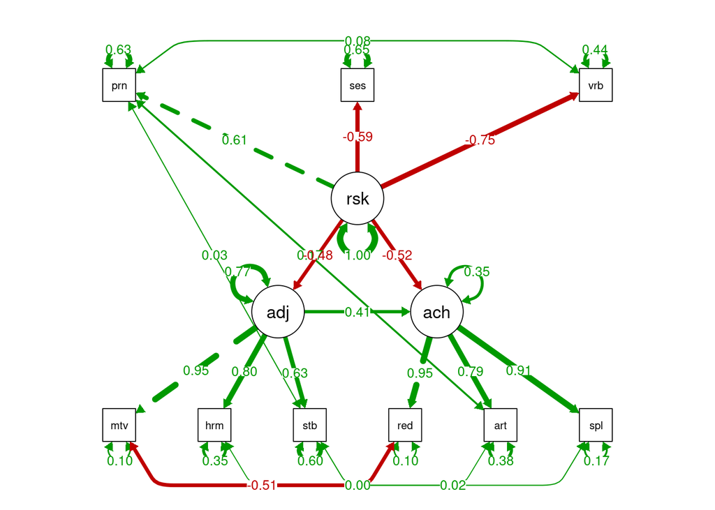

```r
library(semPlot)
semPaths(fit, "std", edge.label.cex = 0.9, curvePivot = TRUE, layout = "tree", fade = FALSE)
```